# lista1

[figure not shown]

**Integrantes**

- Sandro Furtado - 20/0095757
- Tiago Vidigal - 20/0095773
- William Oliveira - 20/0095790

```python
import matplotlib.pyplot as plt
import numpy as np
```

[figure not shown]

**a)** Na situação acima, podemos identificar duas variáveis:

$x_1$: Quantidade de sessões de treinamento de natação;

$x_2$: Quantidade de sessões de treinamento de ciclismo;

Logo, f(x) = x1 + x2

Agora veremos as fórmulas das restrições:

3x1 + 2x2<= 70 #Restrição orçamentária

1500x1 + 1000x2 <= 80.000 #Restrição calórica

2x1 + 2x2 <= 18 #Restrição temporal

x1, x2 >= 1 #Ambas modalidades

Agora vamos plotar as restrições no gráfico:

**Restrição orçamentária**

Assumindo que x1 = 0

3*0 + 2x2 = 70

2x2 = 70

x2 = 70/2 = 35

Assumindo que x2 = 0

3x1 + 2*0 = 70

3x1 = 70

x1 = 70/3 = 23.33

**Restrição calórica**

Assumindo que x1 = 0

1500*0 + 1000x2 = 80.000

1000x2 = 80.000

x2 = 80.000/1.000 = 80

Assumindo que x2 = 0

1500x1 + 1000*0 = 80.000

1500x1 = 80.000

x1 = 80.000/1.500 = 53.33

**Restrição temporal**

Assumindo que x1 = 0

2*0 + 2x2 = 18

2x2 = 18

x2 = 18/2 = 9

Assumindo que x2 = 0

2x1 + 2*0 = 18

2x1 = 18

x1 = 18/2 = 9

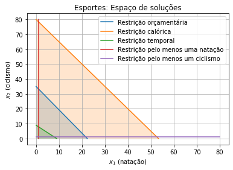

```python
#restrição orçamentária

x1 = [22.33, 0]
y1 = [0, 35]

plt.plot(x1, y1, label = "Restrição orçamentária")
plt.fill_between(x1, y1, [0,0], alpha=0.2)

#restrição calórica
x2 = [53.33, 0]
y2 = [0, 80]

plt.plot(x2, y2, label = "Restrição calórica")
plt.fill_between(x2, y2, [0,0], alpha=0.2)

#restrição temporal
x3 = [9, 0]
y3 = [0, 9]

plt.plot(x3, y3, label = "Restrição temporal")
plt.fill_between(x3, y3, [0,0], alpha=0.2)

x4 = [1, 1]
y4 = [0, 80]

plt.plot(x4, y4, label = "Restrição pelo menos uma natação")

x5 = [0, 80]
y5 = [1, 1]

plt.plot(x5, y5, label = "Restrição pelo menos um ciclismo")

plt.title("Esportes: Espaço de soluções")
plt.xlabel(r"$x_1$ (natação)")
plt.ylabel(r"$x_2$ (ciclismo)")
plt.legend()
plt.grid()
plt.show()
```

**b)**

A região verde do nosso gráfico contem todas as soluções válidas de nosso problema considerando todas as restrições impostas. Como queremos maximizar nossa função objetivo, as soluções ótimas estão em cima da linha verde.

[figure not shown]

**a)**

Boneco: 27 reais

Matéria-Prima: 10 reais

Mão de Obra: 13 reais

Trem: 21 reais

Máreia-Prima: 9 reais

Mão de obra: 10 reais

--- Manufatura ---

Boneco acabamento: 2h

Boneco carpintaria: 1h

Trem acabamento: 1h

Trem carpintaria: 1h

acabamento: 100h

carpintaria: 80h

trens demanda: ilimitada

bonecos demanda: ≤40

f(x) = 4x + 2y (A1) (função objetivo: lucro boneco e trem)

2x + y ≤ 100 (A2) (restrição acabamento)

x + y ≤ 80 (A3) (restrição carpintaria)

x ≤ 40 (A4) (restrição unidades bonecos)

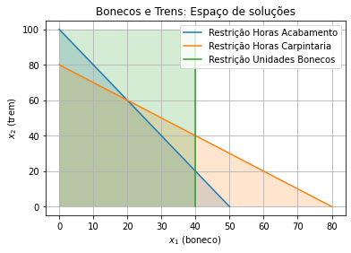

```python
x1 = [50, 0]
y1 = [0, 100]

plt.plot(x1, y1, label = "Restrição Horas Acabamento")
plt.fill_between(x1, y1, [0,0], alpha=0.2)

x2 = [80, 0]
y2 = [0, 80]

plt.plot(x2, y2, label = "Restrição Horas Carpintaria")
plt.fill_between(x2, y2, [0,0], alpha=0.2)

x3 = [40, 40]
y3 = [0, 100]

plt.plot(x3, y3, label = "Restrição Unidades Bonecos")
plt.fill_betweenx(y3, x3, [0,0], alpha=0.2)

plt.title("Bonecos e Trens: Espaço de soluções")
plt.xlabel(r"$x_1$ (boneco)")
plt.ylabel(r"$x_2$ (trem)")
plt.legend()
plt.grid()
plt.show()
```

A região do gráfico que é preenchida pelas 3 cores representa o nosso espaço de soluções válidas considerando todas as restrições.

**b)**

Graficamente, podemos inferir que as soluções ótimas estão sobre a linha que delimita a região referenciada na letra a. Podemos verificar o valor da função objetivo nestes pontos da seguinte forma:

```python
# Região 1: abaixo da linha de Restrição Horas Carpintaria
f1_x1 = np.linspace(0, 19, 20)
f1_x2 = [ 80 - x for x in f1_x1 ]
f1 = []
for i in range(len(f1_x1)):
    f1 += [4*f1_x1[i] + 2*f1_x2[i]]

# Região 2: abaixo da linha de Restrição Horas Acabamento
f2_x1 = np.linspace(20, 40, 21)
f2_x2 = [ 100 - 2*x for x in f2_x1 ]
f2 = []
for i in range(len(f2_x1)):
    f2 += [4*f2_x1[i] + 2*f2_x2[i]]

solucao_otima   = max(f1 + f2)
solucoes_otimas = [f for f in f1 + f2 if f==solucao_otima]
num_solucoes    = len(solucoes_otimas)

print("Solução ótima:         ", solucao_otima)
print("Qtd de soluções ótimas:", num_solucoes)
```

```
Solução ótima:          200.0
Qtd de soluções ótimas: 21
```

Assim, encontramos a solução ótima como sendo 200, a qual ocorre nos 21 pontos delimitados pela linha da Restrição Horas Acabamento dentro da regição de soluções possíveis.

**c)**

Dado a nova função objetivo:

$min\ g(x) = 5x_1 + 3x_2$

Isso é equivalente a:

$max\ g'(x) = -1 * (5x_1 + 3x_2)$

Considerando nossas restrições anteriores, podemos encontrar a solução ótima da nova função objetivo como:

```python
# Região 1: abaixo da linha de Restrição Horas Carpintaria
g1 = []
for i in range(len(f1_x1)):
    g1 += [-1*(5*f1_x1[i] + 3*f1_x2[i])]

# Região 2: abaixo da linha de Restrição Horas Acabamento
g2 = []
for i in range(len(f2_x1)):
    g2 += [-1*(5*f2_x1[i] + 3*f2_x2[i])]

solucao_otima   = max(g1 + g2)
solucoes_otimas = [g for g in g1 + g2 if g==solucao_otima]
num_solucoes    = len(solucoes_otimas)

print("Solução ótima:         ", solucao_otima)
print("Qtd de soluções ótimas:", num_solucoes)
```

```
Solução ótima:          -240.0
Qtd de soluções ótimas: 1
```

Nesta nova função objetivo, possuimos apenas 1 solução ótima para produzir o máximo de brinquedos com menor custo operacional, que será de 240 reais.

[figure not shown]

**a)** Na situação acima, podemos identificar duas variáveis:

$x_1$: Número de unidades de terra com trigo

$x_2$: Número de unidades de terra com milho

A função objetivo que queremos maximizar:

$max\ y = 24x_1 + 8.4x_2$

s.a. $x_1 + x_2 \leq 10$

$20x_1 + 30x_2 \leq 120$

$x_1 \geq 1$

$x_2 \geq 3$

$x_1, x_2 \in \mathbb{Z}$

**b)** Dessa forma, podemos gerar um gráfico para analizar o espaço de soluções:

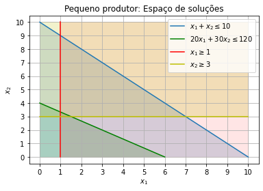

```python
# Restrição 1
x_1 = np.linspace(0, 10, 11)
x_2 = np.linspace(10, 0, 11)
plt.plot(x_1, x_2, label=r"$x_1 + x_2 \leq 10$")
plt.fill_between(x_1, x_2, [0]*11, alpha=0.2)

# Restrição 2
x_1 = np.linspace(0, 6, 7)
x_2 = [(12 - 2*x) / 3 for x in x_1]
plt.plot(x_1, x_2, 'g', label=r"$20x_1 + 30x_2 \leq 120$")
plt.fill_between(x_1, x_2, [0]*7, color='g', alpha=0.2)

# Restrição 3
plt.plot([1,1], [0,10], 'r', label=r"$x_1 \geq 1$")
plt.fill_betweenx([0,10], [1,1], [10,10], color='r', alpha=0.1)

# Restrição 4
plt.plot([0,10], [3,3], 'y', label=r"$x_2 \geq 3$")
plt.fill_between([0,10], [3,3], [10,10], color='y', alpha=0.2)

plt.title("Pequeno produtor: Espaço de soluções")
plt.xlabel(r"$x_1$")
plt.ylabel(r"$x_2$")
plt.xticks(np.linspace(0, 10, 11))
plt.yticks(np.linspace(0, 10, 11))
plt.grid()
plt.legend()
plt.show()
```

**c)** Podemos ver no gráfico acima que nosso espaço de soluções se restringe a uma área bem pequena. Considerando $x_1$ e $x_2$ inteiros (restrição 5), a única combinação possível é:

$x_1 = 1$

$x_2 = 3$

Dessa forma, o pequeno produtor poderá apenas participar no mercado com 1 cultura de trigo e 3 de milho, o mínimo para o consumo interno.

**d)** A restrição do número de unidades de terra (restrição 1) acaba não influenciando, uma vez que a restrição de armazenamento do silo é muito mais rígida. Logo, ela pode ser ignorada sem alterar a solução ótima encontrada.

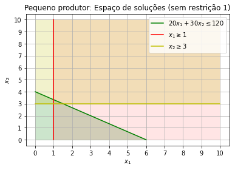

```python
# Restrição 2
x_1 = np.linspace(0, 6, 7)
x_2 = [(12 - 2*x) / 3 for x in x_1]
plt.plot(x_1, x_2, 'g', label=r"$20x_1 + 30x_2 \leq 120$")
plt.fill_between(x_1, x_2, [0]*7, color='g', alpha=0.2)

# Restrição 3
plt.plot([1,1], [0,10], 'r', label=r"$x_1 \geq 1$")
plt.fill_betweenx([0,10], [1,1], [10,10], color='r', alpha=0.1)

# Restrição 4
plt.plot([0,10], [3,3], 'y', label=r"$x_2 \geq 3$")
plt.fill_between([0,10], [3,3], [10,10], color='y', alpha=0.2)

plt.title("Pequeno produtor: Espaço de soluções (sem restrição 1)")
plt.xlabel(r"$x_1$")
plt.ylabel(r"$x_2$")
plt.xticks(np.linspace(0, 10, 11))
plt.yticks(np.linspace(0, 10, 11))
plt.grid()
plt.legend()
plt.show()
```

**e)** Dado o aumento do milho de 0.28 para 1.00 real por kilo, uma alteração é feita na função objetivo. No entanto, as restrições não são afetadas e nosso gráfico de espaço de soluções acima permanece atual. Logo, dado o único par de valores possíveis, a solução ótima é inalterada:

$x_1 = 1$

$x_2 = 3$